# Typical Slaughter Age and Natural Life Span of Animals

Colin Fay

2020-11-29

### 🔎 About the source

Farm Transparency Project - Age of animals slaughtered

farmtransparency.org/kb/abattoirs/48-age-animals-slaughtered

> Most animals are slaughtered as babies, at a very small portion of their natural life span, regardless of whether they are raised conventionally or in operations that are labelled “humane”, “sustainable”, “natural”, “free range”, “cage free”, “heritage bred”, “grass fed”, “local” or “organic”.

### 📈 Visualising the data

Visualization of *Age of animals slaughtered*.

Note: we have rounded numbers using the following patterns:

- We took the upper number when availabe (for example, in `6-8 years`, we kept `8`)
- Months are rounded to 30 days
- Every entry was transformed to a number of seconds, then divided by `86400 * 365.25` to get the value un year.

This visualization compare typical slaughter age (on the left, in green) to the natural lifespan of 14 animals: Chickens (male in egg industry), “Veal” calves, Chickens (broilers / meat breeds), Ducks, Rabbits, Goats, Geese, Turkeys, Pigs, Lambs, “Beef” cattle, Chickens (egg laying hens), Pigs (breeding sows), or Dairy cows.

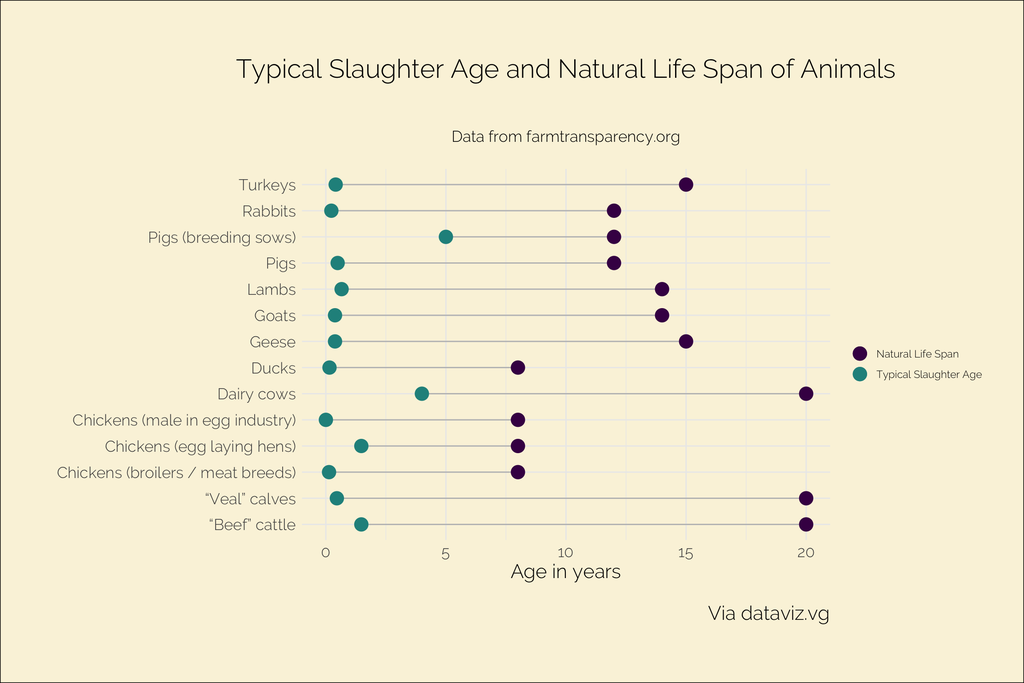

**Show the data**

| Animal | Natural Life Span | Typical Slaughter Age |
| --- | --- | --- |
| Chickens (male in egg industry) | 8 | 0.0027379 |
| “Veal” calves | 20 | 0.4599589 |
| Chickens (broilers / meat breeds) | 8 | 0.1341547 |
| Ducks | 8 | 0.1533196 |
| Rabbits | 12 | 0.2299795 |
| Goats | 14 | 0.3832991 |
| Geese | 15 | 0.3832991 |
| Turkeys | 15 | 0.4106776 |
| Pigs | 12 | 0.4928131 |
| Lambs | 14 | 0.6570842 |
| “Beef” cattle | 20 | 1.4784394 |
| Chickens (egg laying hens) | 8 | 1.4784394 |
| Pigs (breeding sows) | 12 | 5.0000000 |
| Dairy cows | 20 | 4.0000000 |

Code behind this post is available [here](https://github.com/datavizvg/website/blob/main/content/post/2020-11-29-livespan.Rmd).